# Моментум-стратегии и reality check India

> Количество исследумых компаний – **52**

> Период отслеживания менялся от **1** до **12** месяцев

> Период ожидания менялся от **0** до **8** недель

> Период инвестирования менялся от **1** до **12** месяцев

## 1. Моментум стратегии при равных весах. Ранжирование по средней доходности (бенчмарк 6% годовых - только для reality check)

> Всего было рассмотрено **5184** стратегий

#### **Таблица 1. Все стратегии**

|  | mean | t | p-value | hist_per | moment_per | invest_per | percent | Amount_of_negative |
| --- | --- | --- | --- | --- | --- | --- | --- | --- |
| 1 | -0.005612 | 1.041661 | 0.309998 | 4 | 0 | 4 | 0.5 | 13 |
| 2 | -0.002963 | 0.63599 | 0.531994 | 4 | 0 | 8 | 0.5 | 9 |
| 3 | -0.003362 | 0.807819 | 0.428699 | 4 | 0 | 12 | 0.5 | 9 |
| 4 | -0.003063 | 0.820148 | 0.421799 | 4 | 0 | 16 | 0.5 | 10 |
| 5 | -0.002219 | 0.642146 | 0.528071 | 4 | 0 | 20 | 0.5 | 9 |
| 6 | -0.002211 | 0.756848 | 0.457965 | 4 | 0 | 24 | 0.5 | 10 |
| 7 | -6.1e-05 | 0.021885 | 0.982756 | 4 | 0 | 28 | 0.5 | 10 |
| 8 | 0.002101 | 0.763578 | 0.454033 | 4 | 0 | 32 | 0.5 | 6 |
| 9 | 0.002256 | 0.867416 | 0.396003 | 4 | 0 | 36 | 0.5 | 7 |
| 10 | 0.000771 | 0.339921 | 0.73746 | 4 | 0 | 40 | 0.5 | 9 |

[output cut: 5174 more lines]

#### **Рисунок 1.**

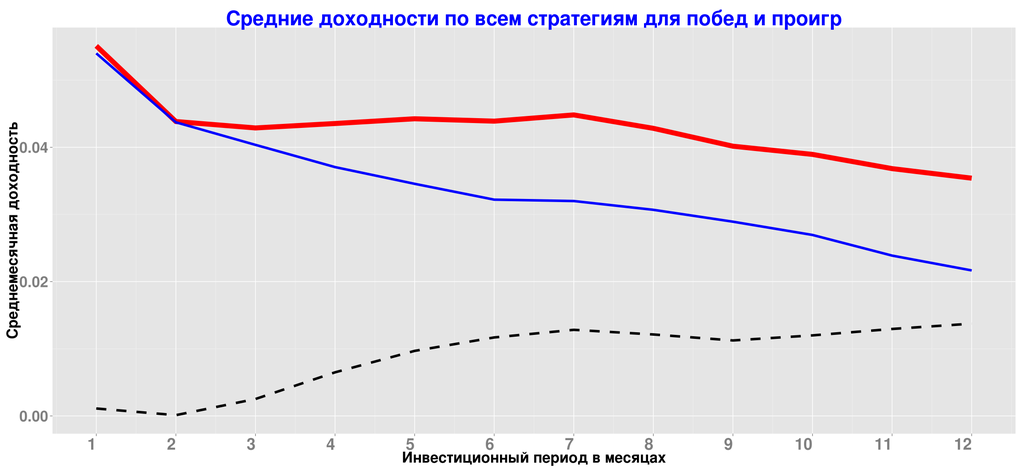

#### **Таблица 2. Агрегированные по всем стратегиям доходности победителей и проигравших**

|  | invest.per | aggr.winner | aggr.loser | delta |
| --- | --- | --- | --- | --- |
| 1 | 1 | 0.0551 | 0.054 | 0.0011 |
| 2 | 2 | 0.0438 | 0.0437 | 0.0001 |
| 3 | 3 | 0.0429 | 0.0404 | 0.0025 |
| 4 | 4 | 0.0435 | 0.0371 | 0.0065 |
| 5 | 5 | 0.0442 | 0.0346 | 0.0097 |
| 6 | 6 | 0.0439 | 0.0322 | 0.0117 |
| 7 | 7 | 0.0448 | 0.032 | 0.0128 |
| 8 | 8 | 0.0428 | 0.0307 | 0.0121 |
| 9 | 9 | 0.0402 | 0.0289 | 0.0112 |
| 10 | 10 | 0.0389 | 0.0269 | 0.012 |

[output cut: 2 more lines]

> Лучшая по средней доходности стратегия дает среднемесячную доходность **4.61** **%** и имеет параметры: период отбора – **1** месяцев, период ожидания – **5** недель, период инвестирования – **1** месяцев, процентиль – **0.1**

> Bootstrap p-value равен **0.306**

> Всего портфелей у лучшей стратегии – **21** Количество отрицательных доходностей у лучшей стратегии – **4** ( **19.05%** )

#### **Рисунок 2.**

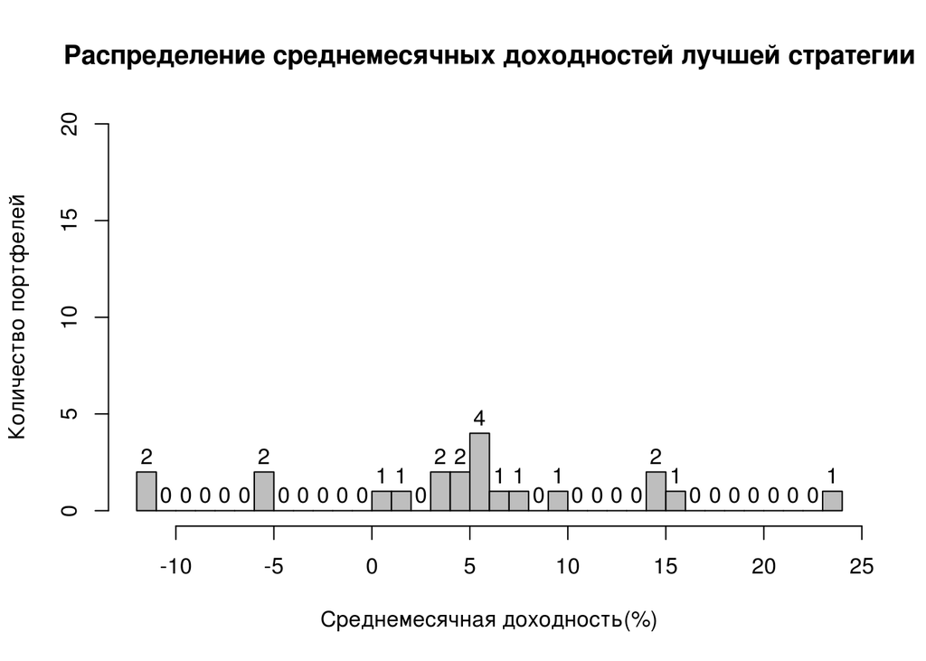

#### **Рисунок 3. (вертикальные пунктирные линии - начало нового года)**

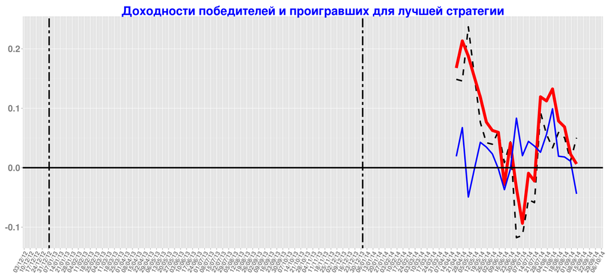

#### **Таблица 3. Доходности победителей и проигравших для лучшей стратегии**

|  | date | Win_portf | Los_portf | Win_Los |
| --- | --- | --- | --- | --- |
| 1 | 2014-04-20 | 0.1678 | 0.0191 | 0.1487 |
| 2 | 2014-04-27 | 0.2133 | 0.0674 | 0.1459 |
| 3 | 2014-05-04 | 0.1878 | -0.0493 | 0.237 |
| 4 | 2014-05-11 | 0.1525 | -0.0026 | 0.1551 |
| 5 | 2014-05-18 | 0.1187 | 0.0427 | 0.076 |
| 6 | 2014-05-25 | 0.0768 | 0.0347 | 0.0421 |
| 7 | 2014-06-01 | 0.0627 | 0.0232 | 0.0395 |
| 8 | 2014-06-08 | 0.0594 | -0.002 | 0.0614 |
| 9 | 2014-06-15 | -0.0284 | -0.037 | 0.0086 |
| 10 | 2014-06-22 | 0.0413 | -0.0021 | 0.0434 |

[output cut: 11 more lines]

### **Вхождение в победителей и проигравших для лучшей стратегии**

#### **Рисунок 4.**

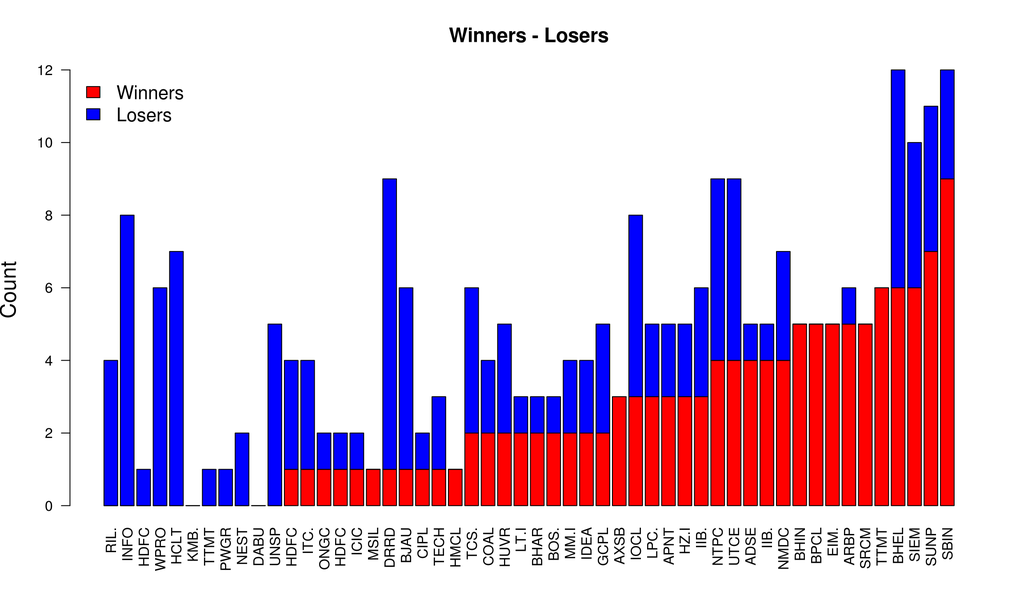

#### **Рисунок 5.**

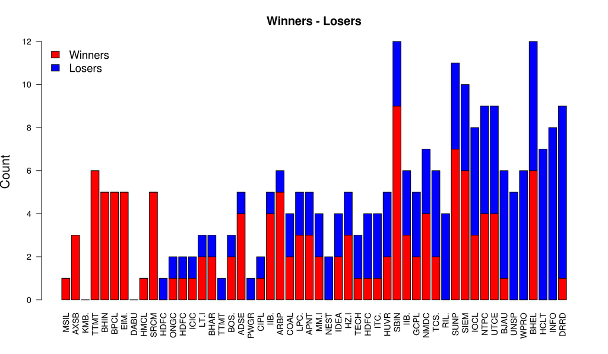

#### **Таблица 4. Вхождение компаний в победители и проигравшие для лучшей по средней доходности стратегии**

|  | Ticket | In_winners | In_losers |
| --- | --- | --- | --- |
| 1 | TCS.IN.Equity | 2 | 4 |
| 2 | HDFCB.F.IN.Equity | 1 | 3 |
| 3 | RIL.IN.Equity | 0 | 4 |
| 4 | ITC.IN.Equity | 1 | 3 |
| 5 | INFO.IN.Equity | 0 | 8 |
| 6 | HDFCB.IN.Equity | 0 | 1 |
| 7 | COAL.IN.Equity | 2 | 2 |
| 8 | SUNP.IN.Equity | 7 | 4 |
| 9 | ONGC.IN.Equity | 1 | 1 |
| 10 | HUVR.IN.Equity | 2 | 3 |

[output cut: 42 more lines]

## 2. Моментум стратегии при равных весах. Ранжирование по t-статистике (бенчмарк 6% годовых - только для reality check)

> Лучшая по t-статистике стратегия дает среднемесячную доходность **2.66** **%** и имеет параметры: период отбора – **11** месяцев, период ожидания – **8** недель, период инвестирования – **12** месяцев, процентиль – **0.1**

> Bootstrap p-value равен **0.106**

> Всего портфелей у лучшей по t-статистике стратегии – **21** Количество отрицательных доходностей у лучшей по t-статистике стратегии – **0** ( **0%** )

#### **Рисунок 6.**

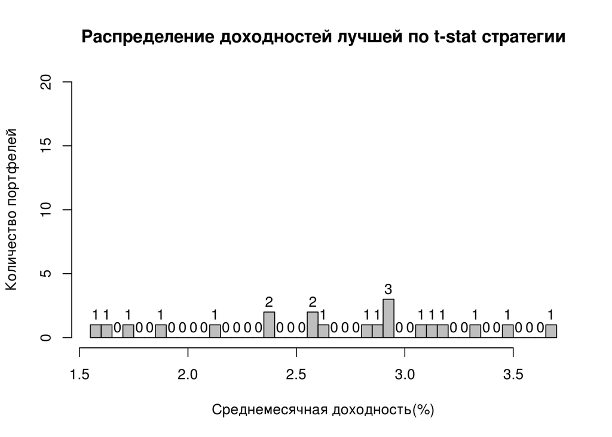

#### **Рисунок 7. (вертикальные пунктирные линии - начало нового года)**

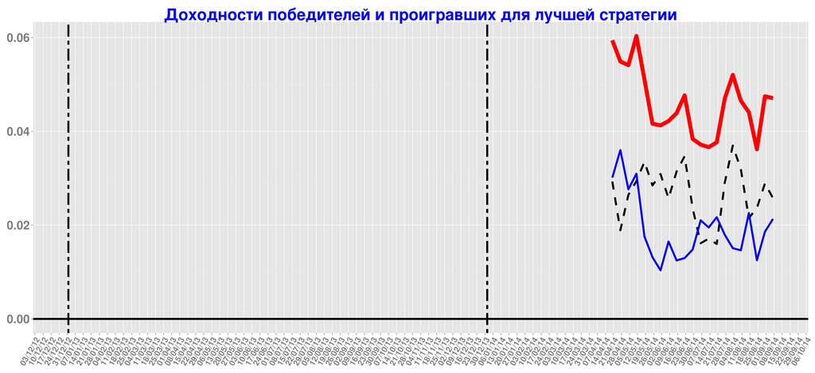

#### **Таблица 5. Доходности победителей и проигравших для лучшей стратегии**

|  | date | Win_portf | Los_portf | Win_Los |
| --- | --- | --- | --- | --- |
| 1 | 2014-04-20 | 0.0594 | 0.0301 | 0.0293 |
| 2 | 2014-04-27 | 0.0549 | 0.036 | 0.0189 |
| 3 | 2014-05-04 | 0.0541 | 0.0276 | 0.0265 |
| 4 | 2014-05-11 | 0.0603 | 0.031 | 0.0294 |
| 5 | 2014-05-18 | 0.0511 | 0.0176 | 0.0335 |
| 6 | 2014-05-25 | 0.0416 | 0.0132 | 0.0285 |
| 7 | 2014-06-01 | 0.0413 | 0.0104 | 0.0309 |
| 8 | 2014-06-08 | 0.0422 | 0.0165 | 0.0257 |
| 9 | 2014-06-15 | 0.0439 | 0.0125 | 0.0314 |
| 10 | 2014-06-22 | 0.0477 | 0.013 | 0.0347 |

[output cut: 11 more lines]

### **Вхождение в победителей и проигравших для лучшей стратегии**

#### **Рисунок 8.**

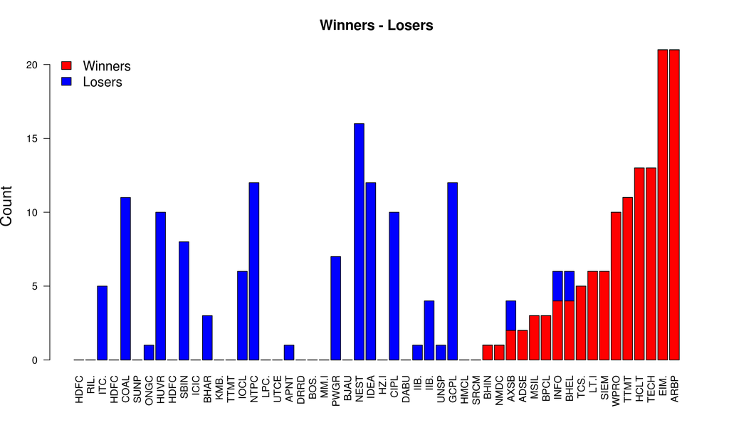

#### **Рисунок 9.**

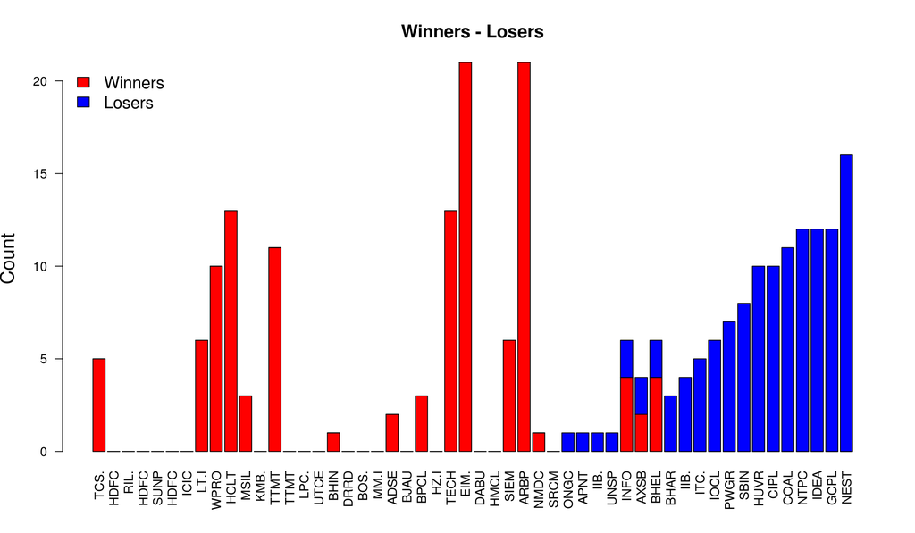

#### **Таблица 6. Вхождение компаний в победители и проигравшие для лучшей по t-статистике стратегии**

|  | Ticket | In_winners | In_losers |
| --- | --- | --- | --- |
| 1 | TCS.IN.Equity | 5 | 0 |
| 2 | HDFCB.F.IN.Equity | 0 | 0 |
| 3 | RIL.IN.Equity | 0 | 0 |
| 4 | ITC.IN.Equity | 0 | 5 |
| 5 | INFO.IN.Equity | 4 | 2 |
| 6 | HDFCB.IN.Equity | 0 | 0 |
| 7 | COAL.IN.Equity | 0 | 11 |
| 8 | SUNP.IN.Equity | 0 | 0 |
| 9 | ONGC.IN.Equity | 0 | 1 |
| 10 | HUVR.IN.Equity | 0 | 10 |

[output cut: 42 more lines]